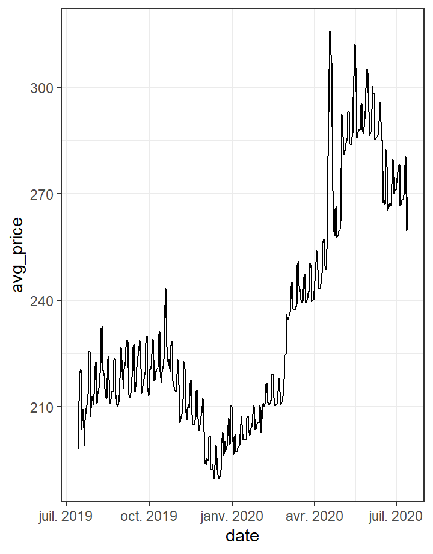

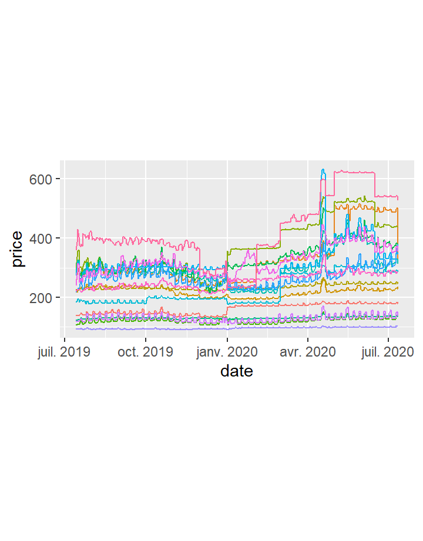

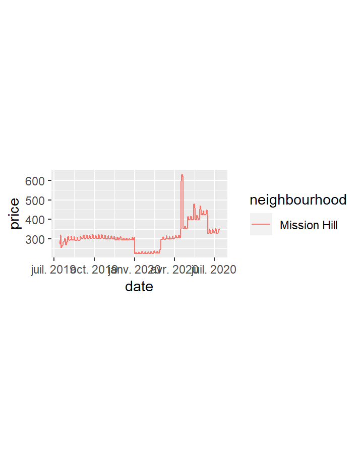

# Average Disponibility per neighbourhood

```
# A tibble: 5 x 2
  neighbourhood    availability_avg
  <chr>                       <dbl>
1 Chestnut Hill              0.0201
2 Leather District           0.0318
3 Brookline                  0.0700
4 Somerville                 0.201
5 Back Bay                   0.238
```

One indicator which we thought of is the average availability. Indeed, the locations in the most wanted neighbourhoods will be more demanded than the others. Making the inverse of the availability a good indicator of neighbourhoods’ attractiveness. Find Above the top five neighbourhoods in terms of that indicator.

# Price Variation Over Time

### Average variation of the prices in Boston

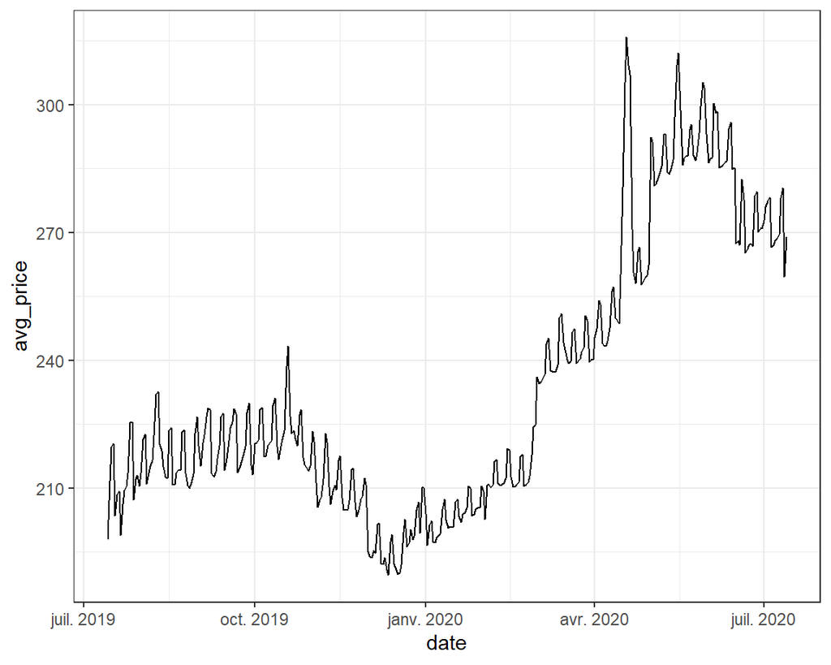

### Prices around April

```
# A tibble: 9 x 2
  date       avg_price
  <date>         <dbl>
1 2020-04-16      281.
2 2020-04-17      305.
3 2020-04-18      316.
4 2020-04-19      309.
5 2020-04-20      307.
6 2020-04-21      271.
7 2020-04-22      261.
8 2020-04-23      258.
9 2020-04-24      266.
```

The evolution of the price around Boston is really straightforward, as there is a normal rise of the average price in the summer. However, there is a weird pike around the end of April, that wecan identify more precisely by selecting the right period of time, from April 17th to April 20th.

There seems to be somthing really interesting happening there, and we might be able to learn more about the location by checking the neighbourhoods where the rise is the steepest.

### Variation of the prices around April

We can see that the prices within the different neighbourhoods vary very differently around that time.

By selecting only Mission Hill, we can see that this neighbourhood is probably very interesting to go around that time. Actually, this spot is on the course of the Boston 2020 marathon, which might be an explanation for it. (see next tab)

### Variation of the different neighbourhood prices

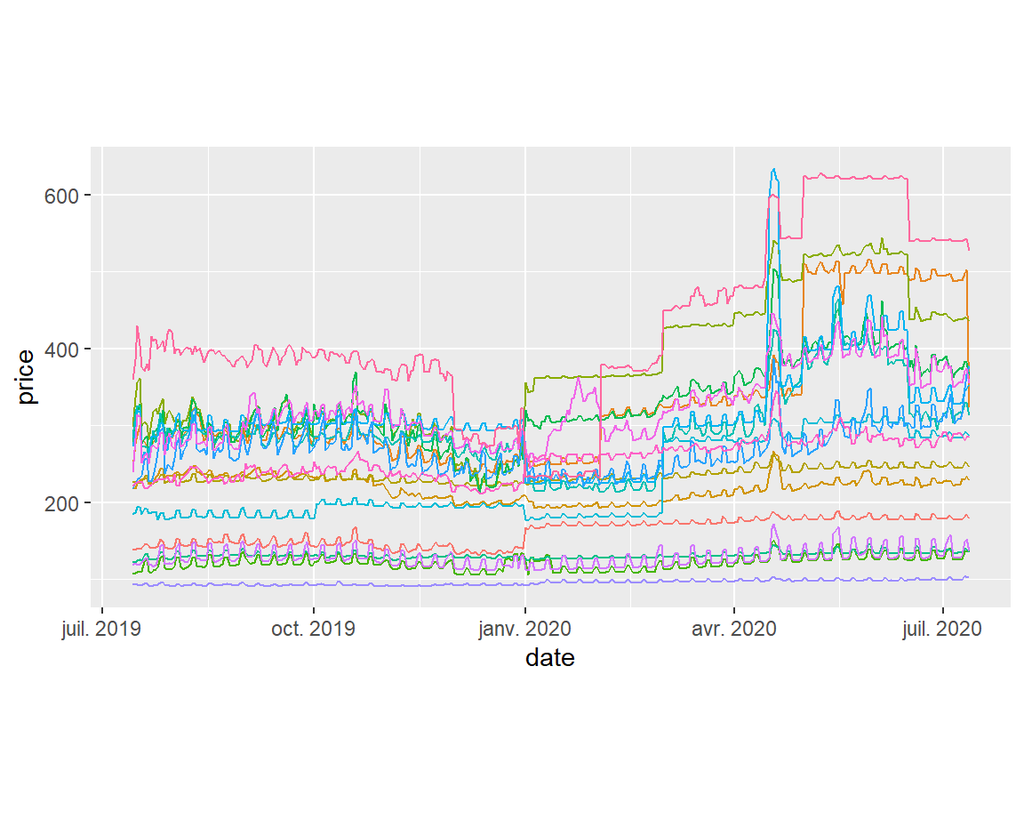

# Mission Hill Overview

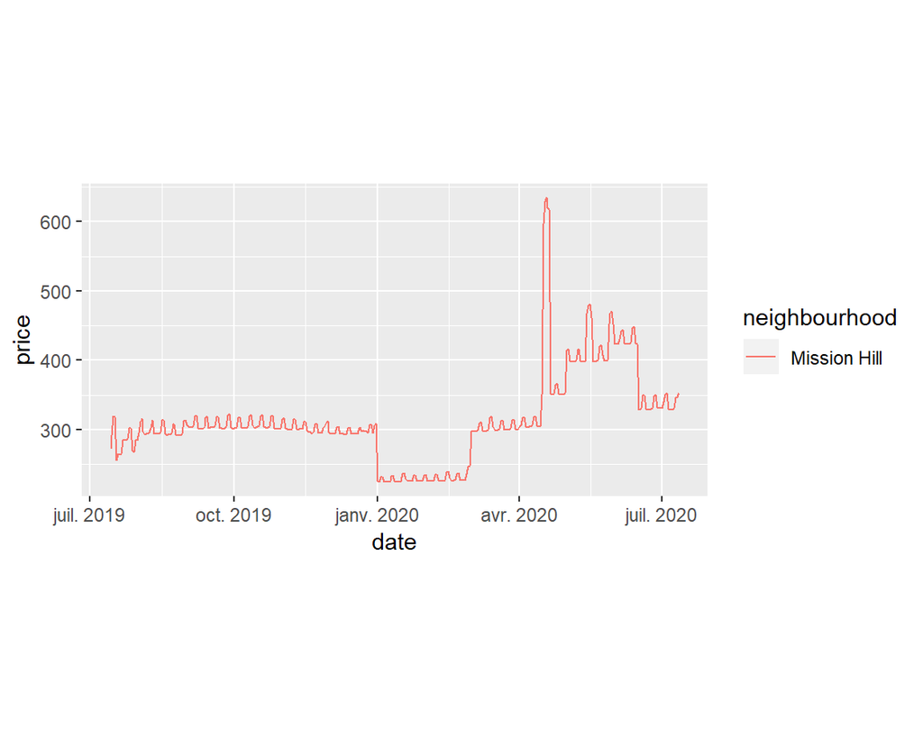

# Users location reviews

```
# A tibble: 5 x 3
  neighbourhood      avg_scores_location number_locations
  <chr>                            <dbl>            <int>
1 Financial District                  10             4015
2 Government Center                   10             4015
3 Brookline                           10             3285
4 Somerville                          10             1825
5 Chestnut Hill                       10             1095
```

Above, we would recommend Financial District and the Government Center. According to the average score location given by the renters. As there are many equal to 10, the maximum, we discriminate by the number of locations, which describes the weigh of the meaning of these scores.